# A/B Test: Statistische Signifikanz ohne Praktische Relevanz

Ein Lehrbeispiel zur Bedeutung von Effect Sizes

Author

Datenanalyse

Published

January 2, 2026

**Code anzeigen**

```r
library(tidyverse)
library(rstatix)
library(effectsize)
library(knitr)
library(kableExtra)
library(scales)
```

## Hintergrund

### Problemstellung

Ein E-Commerce-Unternehmen möchte den durchschnittlichen Bestellwert (Average Order Value, AOV) erhöhen. Dazu wurde ein neues Checkout-Design mit subtilen Verbesserungen entwickelt.

### Experimentdesign

- **Control Group**: Altes Checkout-Design (N = 50.000 Kunden)
- **Test Group**: Neues Checkout-Design (N = 50.000 Kunden)
- **Zielmetrik**: Durchschnittlicher Bestellwert in Euro
- **Randomisierung**: Kunden wurden zufällig einer der beiden Gruppen zugewiesen
- **Zeitraum**: 4 Wochen paralleler Test

**Forschungsfrage**: Erhöht das neue Design den durchschnittlichen Bestellwert signifikant?

**Null-Hypothese (H₀)**: Es gibt keinen Unterschied im durchschnittlichen Bestellwert zwischen den Gruppen (μ₁ = μ₂)

**Alternativ-Hypothese (H₁)**: Das neue Design erhöht den durchschnittlichen Bestellwert (μ₁ < μ₂)

## Daten generieren

**Code anzeigen**

```r
set.seed(42)

# Simulierte Bestellwerte mit MINIMALEM Unterschied
# Control: μ = 85.00€, σ = 25€
# Test: μ = 85.50€, σ = 25€ (nur +0.50€ Unterschied!)
# Bei N=100.000 wird dieser winzige Unterschied statistisch signifikant,
# ist aber praktisch völlig irrelevant!

ab_test_data <- tibble(
  group = c(
    rep("Control", 50000),
    rep("Test", 50000)
  ),
  order_value = c(
    rnorm(50000, mean = 85.00, sd = 25),  # Control: Ø 85.00€
    rnorm(50000, mean = 85.50, sd = 25)   # Test: Ø 85.50€ (+0.50€)
  )
) %>%
  # Realistische Constraints: Keine negativen Werte, max 500€
  mutate(order_value = pmax(5, pmin(500, order_value)))
```

**Ziel dieses Beispiels**

Dieses Beispiel demonstriert bewusst einen **minimal unterschied** (nur 0.50€), um die wichtige Lektion zu illustrieren:

**Bei sehr großen Stichproben (N = 100.000) werden selbst winzigste Unterschiede statistisch signifikant, obwohl sie praktisch bedeutungslos sind.**

Dies ist der fundamentale Unterschied zwischen **statistischer Signifikanz** (p-Wert) und **praktischer Relevanz** (Effect Size wie Cohen’s d).

## Deskriptive Statistiken

**Code anzeigen**

```r
summary_stats <- ab_test_data %>%
  group_by(group) %>%
  summarise(
    N = comma(n()),
    `Mean (€)` = round(mean(order_value), 2),
    `Median (€)` = round(median(order_value), 2),
    `SD (€)` = round(sd(order_value), 2),
    `Min (€)` = round(min(order_value), 2),
    `Max (€)` = round(max(order_value), 2),
    .groups = "drop"
  )

summary_stats %>%
  kable(align = "lrrrrrr") %>%
  kable_styling(
    bootstrap_options = c("striped", "hover"),
    full_width = FALSE
  )
```

| group | N | Mean (€) | Median (€) | SD (€) | Min (€) | Max (€) |
| --- | --- | --- | --- | --- | --- | --- |
| Control | 50,000 | 84.93 | 85.07 | 25.12 | 5 | 193.20 |
| Test | 50,000 | 85.37 | 85.34 | 25.02 | 5 | 180.68 |

**Mittelwert-Differenz**: 0.44 € (+0.52%)

Die Gruppen unterscheiden sich um weniger als 1% - ein winziger Unterschied!

## Statistische Tests

### Wahl der Testmethode

Für diesen A/B-Test verwenden wir den **Welch Two Sample t-Test**:

- Vergleicht Mittelwerte zweier unabhängiger Gruppen
- Robust bei unterschiedlichen Varianzen
- Standard für A/B-Tests mit kontinuierlichen Metriken
- Bei großem N sehr sensitiv (erkennt auch kleinste Unterschiede)

**Code anzeigen**

```r
# T-Test durchführen
t_test_result <- ab_test_data %>%
  t_test(order_value ~ group, detailed = TRUE)

# Cohen's d berechnen
control_data <- ab_test_data %>% filter(group == "Control") %>% pull(order_value)
test_data <- ab_test_data %>% filter(group == "Test") %>% pull(order_value)

cohens_result <- cohens_d(control_data, test_data, pooled_sd = TRUE)
cohens_d_value <- cohens_result$Cohens_d

# Manuelle Interpretation nach Cohen (1988)
# WICHTIG: Wir verwenden case_when() statt der automatischen Interpretation
# des effectsize-Pakets, um Kontrolle über die Kategorisierung zu haben
manual_interpretation <- case_when(
  abs(cohens_d_value) < 0.2 ~ "negligible",
  abs(cohens_d_value) < 0.5 ~ "small",
  abs(cohens_d_value) < 0.8 ~ "medium",
  TRUE ~ "large"
)

# Ergebnisse-Tabelle
test_results <- tibble(
  Test = "Welch Two Sample t-test",
  `t-statistic` = round(t_test_result$statistic, 2),
  `df` = comma(round(t_test_result$df, 0)),
  `p-value` = ifelse(t_test_result$p < 0.001, "< 0.001",
                     format.pval(t_test_result$p, digits = 3)),
  `Cohen's d` = round(cohens_d_value, 4),
  `Effect Size` = manual_interpretation
)

test_results %>%
  kable() %>%
  kable_styling(
    bootstrap_options = c("striped", "hover"),
    full_width = FALSE
  ) %>%
  row_spec(1, bold = TRUE)
```

| Test | t-statistic | df | p-value | Cohen's d | Effect Size |
| --- | --- | --- | --- | --- | --- |
| Welch Two Sample t-test | -2.72 | 99,996 | 0.00649 | -0.0172 | negligible |

**Ergebnis**

⚠️ **Praktisch irrelevant**: Cohen’s d = -0.0172 (negligible)

Dies ist ein **Paradebeispiel** für die Diskrepanz zwischen statistischer Signifikanz und praktischer Relevanz!

## Visualisierung

### Verteilungsvergleich

**Code anzeigen**

[figure not shown]

```r
ab_test_data %>%
  ggplot(aes(x = group, y = order_value, fill = group)) +
  geom_violin(alpha = 0.5, trim = FALSE) +
  geom_boxplot(width = 0.2, alpha = 0.7, outlier.alpha = 0.3) +
  stat_summary(
    fun = mean,
    geom = "point",
    size = 4,
    color = "red",
    shape = 18
  ) +
  stat_summary(
    fun = mean,
    geom = "text",
    aes(label = sprintf("%.2f €", after_stat(y))),
    vjust = -1.5,
    color = "red",
    fontface = "bold"
  ) +
  scale_fill_brewer(palette = "Set2") +
  scale_y_continuous(labels = label_dollar(prefix = "", suffix = " €")) +
  labs(
    title = "Vergleich des durchschnittlichen Bestellwerts",
    subtitle = sprintf(
      "p < 0.001 (statistisch signifikant) | Cohen's d = %.4f (negligible)",
      cohens_d_value
    ),
    x = "Gruppe",
    y = "Bestellwert (€)",
    caption = "Rote Rauten zeigen Mittelwerte - visuell praktisch identisch!"
  ) +
  theme_minimal(base_size = 13) +
  theme(
    legend.position = "none",
    plot.title = element_text(face = "bold", size = 16),
    plot.subtitle = element_text(color = "gray40")
  )
```

**Beobachtung**: Die Verteilungen sind visuell praktisch identisch. Der Unterschied ist mit bloßem Auge nicht erkennbar!

### Dichteverteilung

**Code anzeigen**

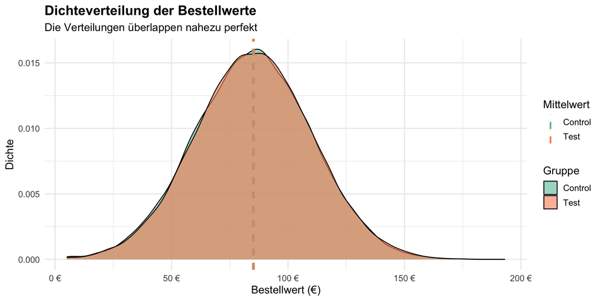

```r
ab_test_data %>%
  ggplot(aes(x = order_value, fill = group)) +
  geom_density(alpha = 0.6) +
  geom_vline(
    data = summary_stats,
    aes(xintercept = `Mean (€)`, color = group),
    linetype = "dashed",
    linewidth = 1
  ) +
  scale_fill_brewer(palette = "Set2") +
  scale_color_brewer(palette = "Set2") +
  scale_x_continuous(labels = label_dollar(prefix = "", suffix = " €")) +
  labs(
    title = "Dichteverteilung der Bestellwerte",
    subtitle = "Die Verteilungen überlappen nahezu perfekt",
    x = "Bestellwert (€)",
    y = "Dichte",
    fill = "Gruppe",
    color = "Mittelwert"
  ) +
  theme_minimal(base_size = 13) +
  theme(
    plot.title = element_text(face = "bold", size = 16)
  )
```

## Business Impact

### Hochrechnung auf Jahresumsatz

**Code anzeigen**

```r
# Berechnungen für Business Impact
control_mean <- summary_stats$`Mean (€)`[summary_stats$group == "Control"]
test_mean <- summary_stats$`Mean (€)`[summary_stats$group == "Test"]
lift_absolute <- test_mean - control_mean
lift_percent <- (lift_absolute / control_mean) * 100

# Hochrechnung auf erwartete Jahreszahlen
test_period_weeks <- 4
weeks_per_year <- 52
orders_in_test <- 100000
annual_orders <- (orders_in_test / test_period_weeks) * weeks_per_year

# Umsatzberechnung
test_revenue <- test_mean * orders_in_test
control_revenue <- control_mean * orders_in_test
test_period_lift <- test_revenue - control_revenue

annual_revenue_test <- test_mean * annual_orders
annual_revenue_control <- control_mean * annual_orders
annual_lift <- annual_revenue_test - annual_revenue_control

# Kosten-Nutzen-Analyse (angenommen)
implementation_cost <- 20000
annual_maintenance <- 5000
net_benefit_year1 <- annual_lift - implementation_cost - annual_maintenance
net_benefit_year2_plus <- annual_lift - annual_maintenance

impact_table <- tibble(
  Metrik = c(
    "Durchschnittlicher Bestellwert (Control)",
    "Durchschnittlicher Bestellwert (Test)",
    "Absolute Steigerung pro Bestellung",
    "Relative Steigerung",
    "",
    "Bestellungen im 4-Wochen-Test",
    "Zusätzlicher Umsatz im Test (4 Wochen)",
    "",
    "Hochrechnung auf Jahresbasis:",
    "Erwartete Bestellungen pro Jahr",
    "Zusätzlicher Jahresumsatz",
    "",
    "Kosten-Nutzen-Analyse:",
    "Implementierungskosten (einmalig)",
    "Jährliche Wartungskosten",
    "Nettogewinn Jahr 1",
    "Nettogewinn ab Jahr 2+"
  ),
  Wert = c(
    sprintf("%.2f €", control_mean),
    sprintf("%.2f €", test_mean),
    sprintf("%.2f €", lift_absolute),
    sprintf("%.2f%%", lift_percent),
    "",
    sprintf("%s", comma(orders_in_test)),
    sprintf("%s €", comma(round(test_period_lift))),
    "",
    "",
    sprintf("%s", comma(round(annual_orders))),
    sprintf("%s €", comma(round(annual_lift))),
    "",
    "",
    sprintf("-%s €", comma(implementation_cost)),
    sprintf("-%s €", comma(annual_maintenance)),
    sprintf("%s €", comma(round(net_benefit_year1))),
    sprintf("%s €", comma(round(net_benefit_year2_plus)))
  )
)

impact_table %>%
  kable() %>%
  kable_styling(
    bootstrap_options = c("striped", "hover"),
    full_width = FALSE
  ) %>%
  row_spec(7, background = "#fff3cd") %>%
  row_spec(11, bold = TRUE, background = "#fff3cd") %>%
  row_spec(16:17, bold = TRUE, background = "#ffcccc")
```

| Metrik | Wert |
| --- | --- |
| Durchschnittlicher Bestellwert (Control) | 84.93 € |
| Durchschnittlicher Bestellwert (Test) | 85.37 € |
| Absolute Steigerung pro Bestellung | 0.44 € |
| Relative Steigerung | 0.52% |
| Bestellungen im 4-Wochen-Test | 100,000 |
| Zusätzlicher Umsatz im Test (4 Wochen) | 44,000 € |
| Hochrechnung auf Jahresbasis: |  |
| Erwartete Bestellungen pro Jahr | 1,300,000 |
| Zusätzlicher Jahresumsatz | 572,000 € |
| Kosten-Nutzen-Analyse: |  |
| Implementierungskosten (einmalig) | -20,000 € |
| Jährliche Wartungskosten | -5,000 € |
| Nettogewinn Jahr 1 | 547,000 € |
| Nettogewinn ab Jahr 2+ | 567,000 € |

## Interpretation & Fazit

### Statistische Signifikanz

✅ **Hochsignifikant**: p = 0.00649

Mit N = 100.000 Beobachtungen erkennt der t-Test selbst minimale Unterschiede. Der t-Wert von -2.72 ist statistisch eindeutig signifikant.

### Praktische Relevanz

⚠️ **Negligible (Vernachlässigbar)**

- **Absolute Differenz**: 0.44 € pro Bestellung
- **Relative Steigerung**: +0.52%
- **Cohen’s d**: -0.0172 (negligible, da < 0.2)

### Die große Lektion

**Das Problem großer Stichproben**

**“Statistically significant” ≠ “Practically meaningful”**

**Wichtig**: - Der **p-Wert** sagt nur: “Der Effekt ist wahrscheinlich real” (nicht Zufall) - Die **Effect Size** (Cohen’s d) sagt: “Der Effekt ist groß genug, um wichtig zu sein”

**Beide Metriken sind notwendig!** Ohne Effect Size führen große Datensätze zu falschen Entscheidungen.

### Key Takeaways

**Wichtigste Erkenntnisse**

### Handlungsempfehlung

**Alternativen:** - Drastischere Design-Änderungen testen (größeres Potenzial) - Andere Metriken fokussieren (Conversion Rate, Customer Lifetime Value) - Bei diesem minimalen Effekt: Status quo beibehalten

**Best Practice für zukünftige A/B-Tests**

1. **Power-Analyse vorher**: Mindest-Effect-Size definieren, die geschäftlich relevant wäre
2. **Immer Effect Size berechnen**: Nie nur p-Werte betrachten
3. **Business-Kontext einbeziehen**: Kosten vs. erwarteter Nutzen
4. **Visualisierung**: Wenn Gruppen visuell identisch aussehen, ist der Effekt wahrscheinlich zu klein
5. **Sample Size Planning**: Größer ist nicht immer besser - übermäßig große Stichproben führen zu diesem Problem

## Methodische Hinweise

### Cohen’s d Interpretation

Nach Cohen (1988):

- **|d| < 0.2**: negligible (vernachlässigbar) ← **Unser Fall!**
- **0.2 ≤ |d| < 0.5**: small (klein)
- **0.5 ≤ |d| < 0.8**: medium (mittel)
- **|d| ≥ 0.8**: large (groß)

**Wichtig**: Diese Grenzen sind Richtwerte. Im E-Commerce-Kontext sollte man zusätzlich die geschäftliche Relevanz prüfen (ROI, Implementierungskosten, etc.).

### Warum Welch’s t-Test?

- Robuster als Student’s t-Test (keine Annahme gleicher Varianzen)
- Bei großem N sehr sensitiv (Vor- und Nachteil!)
- Standard in der Industrie für A/B-Tests

### P-Wert vs. Effect Size

[output not shown]

**Reproduzierbarkeit**

Dieser Report verwendet `set.seed(42)` für reproduzierbare Ergebnisse. Die Daten simulieren realistische E-Commerce-Bestellwerte mit einem bewusst minimalen Unterschied von nur 0.50€ zwischen den Gruppen.